# My Achievement:

Through the completion of these tasks, I successfully explored the impact of differential privacy on machine learning models, specifically clustering and regression. In Task 1, I analyzed how varying the privacy budget (epsilon) affects clustering performance using differentially private K-means. The results demonstrated a clear tradeoff between privacy and utility, with higher epsilon values leading to better-defined clusters and more accurate alignment with ground truth labels. Similarly, in Task 2, I investigated the effect of epsilon on regression performance using differentially private linear regression. The analysis showed that at low epsilon values, excessive noise severely impacts model accuracy, while higher epsilon values yield stable and near-optimal performance. These tasks provided valuable insights into the practical implementation of privacy-preserving machine learning and highlighted the importance of balancing privacy guarantees with model utility.

# ✍ Student: Mohammad Osmanpoor

# 🏢 University: Macquarie University

# 📅 Assignment: Week 6 Workshop

# ✍ **Task 1**. Study how eplison affects the clustering performance via visualizing the relationship between epsilon and the cluster performance indicators we used in Workshop Week 4.

You could fix value of K for the number of clusters, e.g., 5, or 10. To facilitate your task, the epsilon range and values are given in the following code. But you are free to change them to explore other values with appropriate justification.

Note that when epsilon is big enough, the model could be equivalent to the original version without noise addition. So, you can have a comparison between an original model and the differential private version.

The range of epsilon in the following is within $10^{-4}$ and $10$.

```python
# We need to calculate the performance indicators for measuring the cluster quality.
# db_scores = []
# db_scores_std = []

# ar_scores=[]
# ar_scores_std=[]

# inertia = []
# inertia_std = []

# # The privacy budget range and values are given
# epsilons = np.logspace(-4, 1, 20)
# print("\nprivacy budgets (epsilons): \n", epsilons)

# write your code here ...
```

```python
pip install -q diffprivlib
```

```python
# Just ignore the warnings
import warnings
warnings.filterwarnings("ignore")
```

```python
# Import necessary libraries
import math
import numpy as np
import pandas as pd
from matplotlib import pyplot as plt
import warnings
warnings.filterwarnings("ignore")

# Import the Iris dataset
from sklearn import datasets
dataset = datasets.load_iris()
X = dataset.data
y = dataset.target

# Import the differential private version of KMeans and metrics
from diffprivlib.models import KMeans
from sklearn.metrics import davies_bouldin_score, adjusted_rand_score
```

```python
# Initialize lists to store performance metrics
db_scores = []  # Davies-Bouldin scores
db_scores_std = []  # Standard deviation of DB scores
ar_scores = []  # Adjusted Rand scores
ar_scores_std = []  # Standard deviation of AR scores
inertia = []  # Average inertia
inertia_std = []  # Standard deviation of inertia

# Define privacy budget range (epsilon values)
epsilons = np.logspace(-4, 1, 20)  # 20 values from 10^-4 to 10^1
print("\nPrivacy budgets (epsilons): \n", epsilons)

# Number of iterations for each epsilon value to get stable results
n_iterations = 10
n_clusters = 5  # Fixed number of clusters
```

```
Privacy budgets (epsilons):
 [1.00000000e-04 1.83298071e-04 3.35981829e-04 6.15848211e-04
 1.12883789e-03 2.06913808e-03 3.79269019e-03 6.95192796e-03
 1.27427499e-02 2.33572147e-02 4.28133240e-02 7.84759970e-02
 1.43844989e-01 2.63665090e-01 4.83293024e-01 8.85866790e-01
 1.62377674e+00 2.97635144e+00 5.45559478e+00 1.00000000e+01]
```

```python
# Iterate through each epsilon value
for eps in epsilons:
    # Lists to store results for current epsilon
    db_scores_tmp = []
    ar_scores_tmp = []
    inertias_tmp = []

    # Run multiple iterations for each epsilon to get stable metrics
    for i in range(n_iterations):
        # Create and fit the differentially private KMeans model
        # Not specifying bounds will cause a warning but will calculate bounds from data
        kmeans = KMeans(epsilon=eps, n_clusters=n_clusters)
        kmeans.fit(X)
        labels = kmeans.labels_

        # Calculate performance metrics
        db_scores_tmp.append(davies_bouldin_score(X, labels))
        ar_scores_tmp.append(adjusted_rand_score(labels, y))
        inertias_tmp.append(math.sqrt(kmeans.inertia_/X.shape[0]))  # Normalized inertia

    # Calculate mean and standard deviation for each metric
    db_scores.append(np.mean(db_scores_tmp))
    db_scores_std.append(np.std(db_scores_tmp))
    ar_scores.append(np.mean(ar_scores_tmp))
    ar_scores_std.append(np.std(ar_scores_tmp))
    inertia.append(np.mean(inertias_tmp))
    inertia_std.append(np.std(inertias_tmp))
```

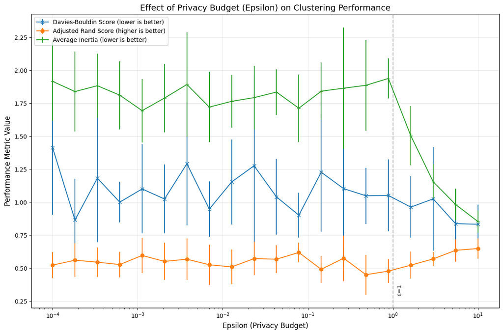

```python
# Create a figure with appropriate size
plt.figure(figsize=(12, 8))

# Plot the relationship between epsilon and performance metrics with error bars
plt.errorbar(epsilons, db_scores, yerr=db_scores_std, marker='x', label='Davies-Bouldin Score (lower is better)')
plt.errorbar(epsilons, ar_scores, yerr=ar_scores_std, marker='o', label='Adjusted Rand Score (higher is better)')
plt.errorbar(epsilons, inertia, yerr=inertia_std, marker='+', label='Average Inertia (lower is better)')

# Set plot properties
plt.xscale('log')  # Use logarithmic scale for x-axis to better visualize the range
plt.title('Effect of Privacy Budget (Epsilon) on Clustering Performance', fontsize=14)
plt.xlabel('Epsilon (Privacy Budget)', fontsize=12)
plt.ylabel('Performance Metric Value', fontsize=12)
plt.grid(True, alpha=0.3)
plt.legend(loc='best', fontsize=10)

# Add vertical line at epsilon=1 for reference (common privacy budget value)
plt.axvline(x=1, color='gray', linestyle='--', alpha=0.5)
plt.text(1.1, plt.ylim()[0] + 0.1, 'ε=1', rotation=90, alpha=0.7)

# Show the plot
plt.tight_layout()
plt.show()
```

```python
# Create a table to display the numeric results
results_df = pd.DataFrame({
    'Epsilon': epsilons,
    'Davies-Bouldin Score': db_scores,
    'DB Score Std': db_scores_std,
    'Adjusted Rand Score': ar_scores,
    'AR Score Std': ar_scores_std,
    'Average Inertia': inertia,
    'Inertia Std': inertia_std
})

# Display the table with rounded values for better readability
print("\nPerformance metrics for different epsilon values:")
pd.set_option('display.precision', 4)
print(results_df)
```

```
Performance metrics for different epsilon values:
    Epsilon  Davies-Bouldin Score  DB Score Std  Adjusted Rand Score  \
0    0.0001                1.4132        0.5067               0.5237
1    0.0002                0.8653        0.3109               0.5611
2    0.0003                1.1823        0.4866               0.5460
3    0.0006                1.0005        0.1534               0.5279
4    0.0011                1.1008        0.3377               0.5970
5    0.0021                1.0246        0.2600               0.5517
6    0.0038                1.2920        0.4669               0.5686
7    0.0070                0.9480        0.2106               0.5263
8    0.0127                1.1540        0.3216               0.5102
9    0.0234                1.2763        0.6753               0.5730
10   0.0428                1.0407        0.2865               0.5685
11   0.0785                0.9017        0.1700               0.6195
12   0.1438                1.2275        0.4509               0.4916
```

[output cut: 29 more lines]

```python
# Identify the best epsilon values for each metric
best_db_idx = np.argmin(db_scores)
best_ar_idx = np.argmax(ar_scores)
best_inertia_idx = np.argmin(inertia)

print("\nBest epsilon for Davies-Bouldin Score:", epsilons[best_db_idx])
print("Best epsilon for Adjusted Rand Score:", epsilons[best_ar_idx])
print("Best epsilon for Average Inertia:", epsilons[best_inertia_idx])
```

```
Best epsilon for Davies-Bouldin Score: 10.0
Best epsilon for Adjusted Rand Score: 10.0
Best epsilon for Average Inertia: 10.0
```

# ✍ My Observations

# ✍ **Question**: Run the code with $\epsilon$ up to $10^2$. What's your observation from the plot? How can you explain the changes of the trends?

```
Privacy budgets (epsilons):
 [1.00000000e-04 1.77827941e-04 3.16227766e-04 5.62341325e-04
 1.00000000e-03 1.77827941e-03 3.16227766e-03 5.62341325e-03
 1.00000000e-02 1.77827941e-02 3.16227766e-02 5.62341325e-02
 1.00000000e-01 1.77827941e-01 3.16227766e-01 5.62341325e-01
 1.00000000e+00 1.77827941e+00 3.16227766e+00 5.62341325e+00
 1.00000000e+01 1.77827941e+01 3.16227766e+01 5.62341325e+01
 1.00000000e+02]
```

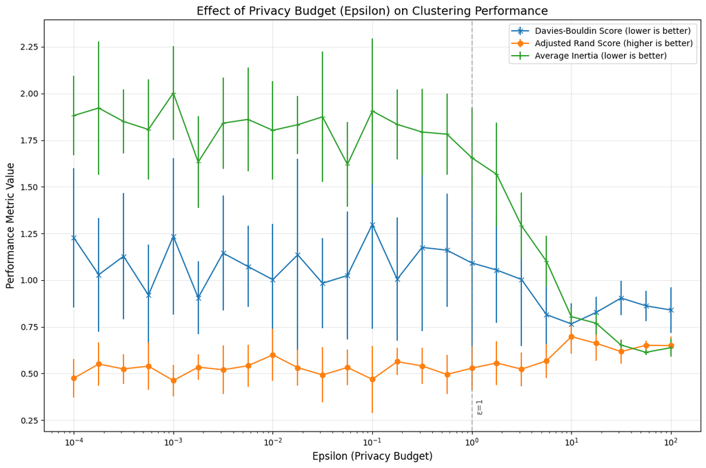

```
Performance metrics for different epsilon values:
     Epsilon  Davies-Bouldin Score  DB Score Std  Adjusted Rand Score  \
0     0.0001                1.2272        0.3730               0.4749
1     0.0002                1.0291        0.3050               0.5507
2     0.0003                1.1279        0.3376               0.5244
3     0.0006                0.9201        0.2700               0.5395
4     0.0010                1.2343        0.4188               0.4623
5     0.0018                0.9059        0.1961               0.5343
6     0.0032                1.1451        0.3080               0.5201
7     0.0056                1.0731        0.2170               0.5414
8     0.0100                1.0027        0.2994               0.5999
9     0.0178                1.1359        0.5139               0.5317
10    0.0316                0.9834        0.2422               0.4925
11    0.0562                1.0251        0.3417               0.5326
12    0.1000                1.2984        0.5574               0.4688
```

[output cut: 43 more lines]

```python
# for answerting this question, I have extended the code up to epsilon e+2


dataset = datasets.load_iris()
X = dataset.data
y = dataset.target

# Import the differential private version of KMeans and metrics
from diffprivlib.models import KMeans
from sklearn.metrics import davies_bouldin_score, adjusted_rand_score

# Initialize lists to store performance metrics
db_scores = []  # Davies-Bouldin scores
db_scores_std = []  # Standard deviation of DB scores
ar_scores = []  # Adjusted Rand scores
ar_scores_std = []  # Standard deviation of AR scores
inertia = []  # Average inertia
inertia_std = []  # Standard deviation of inertia

# Define privacy budget range (epsilon values) - extended to 10^2
epsilons = np.logspace(-4, 2, 25)  # 25 values from 10^-4 to 10^2
print("\nPrivacy budgets (epsilons): \n", epsilons)

# Number of iterations for each epsilon value to get stable results
n_iterations = 10
n_clusters = 5  # Fixed number of clusters

# Iterate through each epsilon value
for eps in epsilons:
    # Lists to store results for current epsilon
    db_scores_tmp = []
    ar_scores_tmp = []
    inertias_tmp = []

    # Run multiple iterations for each epsilon to get stable metrics
    for i in range(n_iterations):
        # Create and fit the differentially private KMeans model
        kmeans = KMeans(epsilon=eps, n_clusters=n_clusters)
        kmeans.fit(X)
        labels = kmeans.labels_

        # Calculate performance metrics
        db_scores_tmp.append(davies_bouldin_score(X, labels))
        ar_scores_tmp.append(adjusted_rand_score(labels, y))
        inertias_tmp.append(math.sqrt(kmeans.inertia_/X.shape[0]))  # Normalized inertia

    # Calculate mean and standard deviation for each metric
    db_scores.append(np.mean(db_scores_tmp))
    db_scores_std.append(np.std(db_scores_tmp))
    ar_scores.append(np.mean(ar_scores_tmp))
    ar_scores_std.append(np.std(ar_scores_tmp))
    inertia.append(np.mean(inertias_tmp))
    inertia_std.append(np.std(inertias_tmp))

# Create a figure with appropriate size
plt.figure(figsize=(12, 8))

# Plot the relationship between epsilon and performance metrics with error bars
plt.errorbar(epsilons, db_scores, yerr=db_scores_std, marker='x', label='Davies-Bouldin Score (lower is better)')
plt.errorbar(epsilons, ar_scores, yerr=ar_scores_std, marker='o', label='Adjusted Rand Score (higher is better)')
plt.errorbar(epsilons, inertia, yerr=inertia_std, marker='+', label='Average Inertia (lower is better)')

# Set plot properties
plt.xscale('log')  # Use logarithmic scale for x-axis to better visualize the range
plt.title('Effect of Privacy Budget (Epsilon) on Clustering Performance', fontsize=14)
plt.xlabel('Epsilon (Privacy Budget)', fontsize=12)
plt.ylabel('Performance Metric Value', fontsize=12)
plt.grid(True, alpha=0.3)
plt.legend(loc='best', fontsize=10)

# Add vertical line at epsilon=1 for reference (common privacy budget value)
plt.axvline(x=1, color='gray', linestyle='--', alpha=0.5)
plt.text(1.1, plt.ylim()[0] + 0.1, 'ε=1', rotation=90, alpha=0.7)

# Show the plot
plt.tight_layout()
plt.show()

# Create a table to display the numeric results
results_df = pd.DataFrame({
    'Epsilon': epsilons,
    'Davies-Bouldin Score': db_scores,
    'DB Score Std': db_scores_std,
    'Adjusted Rand Score': ar_scores,
    'AR Score Std': ar_scores_std,
    'Average Inertia': inertia,
    'Inertia Std': inertia_std
})

# Display the table with rounded values for better readability
print("\nPerformance metrics for different epsilon values:")
pd.set_option('display.precision', 4)
print(results_df)

# Identify the best epsilon values for each metric
best_db_idx = np.argmin(db_scores)
best_ar_idx = np.argmax(ar_scores)
best_inertia_idx = np.argmin(inertia)

print("\nBest epsilon for Davies-Bouldin Score:", epsilons[best_db_idx])
print("Best epsilon for Adjusted Rand Score:", epsilons[best_ar_idx])
print("Best epsilon for Average Inertia:", epsilons[best_inertia_idx])
```